# Lab 8, Part 2: Time Series Exploration with tsibble

Shuying Yu

2/24/2022

```r
knitr::opts_chunk$set(echo = TRUE, warning=FALSE, message=FALSE)

#Attach packages
library(tidyverse)
library(here)
library(lubridate)
library(tsibble)
library(feasts) #time series stats
library(slider)
```

# Look at the data

Toolik Station (LTER) meteorological data (Source: Source: Shaver, G. 2019. A multi-year DAILY file for the Toolik Field Station at Toolik Lake, AK starting 1988 to present. ver 4. Environmental Data Initiative.)

Notice that the date parsed (assumed class) as *character.* That limits the nice time series features we can use, so we’ll quickly convert it into a tsibble (a time series data frame) so that we can use functions in `feasts` and `fable` to explore & analyze it.

```r
#Read in the data
#Weather data from Toolik
toolik <- read_csv(here("data","toolikweather.csv"))
```

```r
#Plot
ggplot(data = toolik, aes(x = date, y = mean_airtemp)) +
  geom_line()

# Booo we get a warning (only one observation per series)
```

Notice that it doesn’t work - because R doesn’t understand the date is a *date* until we tell it.

Let’s go ahead and convert it to a tsibble using the `as_tsibble()` function. First, we’ll need to convert the date to a `date` class, *then* convert to a tsibble:

```r
#Convert to tsibble: df with special characteristics that it is a time series
toolik_ts <- toolik %>%

  #Take MDY of data column into propoer data column
  #Date rather than character column
  mutate(date = lubridate::mdy(date)) %>%

  #Class not time series yet
  #index is what's used for later, use as time series index
  as_tsibble(key = NULL, index = date)
```

Now let’s plot it:

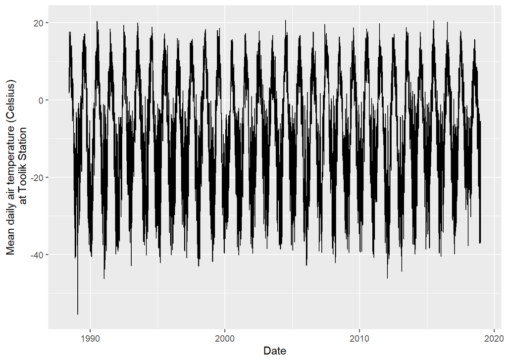

```r
ggplot(data = toolik_ts, aes(x = date, y = mean_airtemp)) +
  geom_line() +
  labs(x = "Date",
       y = "Mean daily air temperature (Celsius)\n at Toolik Station")
```

We need to ask some big picture questions at this point, like:

# Use `index_by()` to aggregate time series by increments

We will use `index_by()` instead of `group_by()` to do the trick. See `?index_by()` to group by a time index, then `summarize()` to specify what to calulate & return for each interval.

```r
toolik_month <- toolik_ts %>%

  #In df we group by then summarize
  #Here we use index_by which is specific for time series tibbles
  #We index by year and month, create new column yr_mo
  index_by(yr_mo = ~yearmonth(.)) %>%

  #Summarize omnthly mean temp
  summarize(monthly_mean_temp = mean(mean_airtemp, na.rm = TRUE))
```

Now let’s take a look:

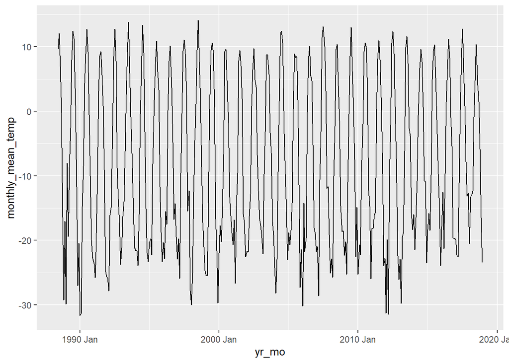

```r
#Plot with monthly summary
ggplot(data = toolik_month, aes(x = yr_mo, y = monthly_mean_temp)) +
  geom_line()
```

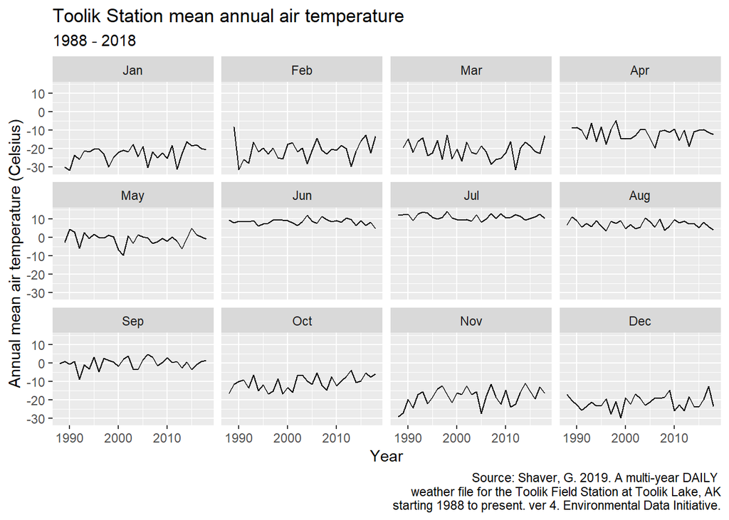

```r
#Or break it up by month:
toolik_month %>%

  #Extract year using lubridate on the x-axis
  ggplot(aes(x = year(yr_mo), y = monthly_mean_temp)) +
  geom_line() +

  #Use facet wrap to break it up by month
  facet_wrap(~month(yr_mo, label = TRUE)) +
  labs(x = "Year",
       y = "Annual mean air temperature (Celsius)",
       title = "Toolik Station mean annual air temperature",
       subtitle = "1988 - 2018",
       caption = "Source: Shaver, G. 2019. A multi-year DAILY \nweather file for the Toolik Field Station at Toolik Lake, AK\n starting 1988 to present. ver 4. Environmental Data Initiative.")
```

Can you do other increments with `index_by()`? Absolutely! **See `?index_by()` for grouping options!**

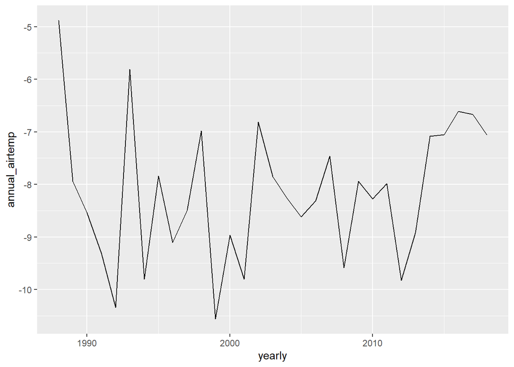

```r
toolik_annual <- toolik_ts %>%
  index_by(yearly = ~year(.)) %>%
  summarize(annual_airtemp = mean(mean_airtemp, na.rm = TRUE))

ggplot(data = toolik_annual, aes(x = yearly, y = annual_airtemp)) +
  geom_line()
```

Average temperatured across the entire time period

And how about a weekly average?

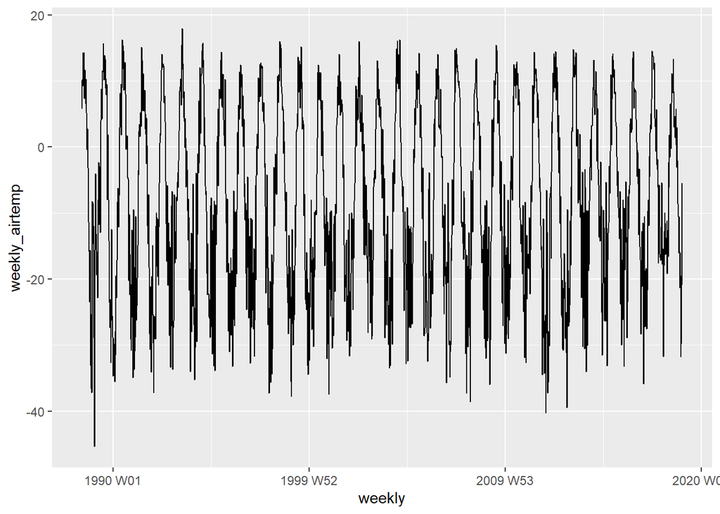

```r
toolik_weekly <- toolik_ts %>%
  index_by(weekly = ~yearweek(.)) %>%
  summarize(weekly_airtemp = mean(mean_airtemp, na.rm = TRUE))

ggplot(data = toolik_weekly, aes(x = weekly, y = weekly_airtemp)) +
  geom_line()
```

# Use `filter_index()` to filter by date-times!

Can still use same type of functions we’ve been using with regular tibbles and dataframes.

We can use `filter_index()` specifically to help us filter data by time spans. See `?filter_index()` for more information.

**Example 1:** Filter from June 2000 through October 2001

```r
toolik_ts %>%
  filter_index("2000-06" ~ "2001-10")
```

```
## # A tsibble: 518 x 5 [1D]
##    date       station              mean_airtemp daily_precip mean_windspeed
##    <date>     <chr>                       <dbl>        <dbl>          <dbl>
##  1 2000-06-01 Toolik Field Station          2.5          0              3.8
##  2 2000-06-02 Toolik Field Station         -3            6.6            2.3
##  3 2000-06-03 Toolik Field Station         -1.3          0.8            2.1
##  4 2000-06-04 Toolik Field Station          4.8          1.3            2
##  5 2000-06-05 Toolik Field Station          8.5          0              3.2
##  6 2000-06-06 Toolik Field Station         12.8          0.8            4.1
##  7 2000-06-07 Toolik Field Station         12.9          0              2.8
##  8 2000-06-08 Toolik Field Station          9.5          0              3.2
##  9 2000-06-09 Toolik Field Station          9.6          1              2.7
## 10 2000-06-10 Toolik Field Station         12.3          0              3.1
## # ... with 508 more rows
```

**Example 2:** Filter from April 10, 2006 to May 15, 2006

```r
toolik_ts %>%
  filter_index("2006-04-10" ~ "2006-05-15")
```

```
## # A tsibble: 36 x 5 [1D]
##    date       station              mean_airtemp daily_precip mean_windspeed
##    <date>     <chr>                       <dbl>        <dbl>          <dbl>
##  1 2006-04-10 Toolik Field Station        -18.5            0             NA
##  2 2006-04-11 Toolik Field Station        -13.5            0             NA
##  3 2006-04-12 Toolik Field Station        -22.5            0             NA
##  4 2006-04-13 Toolik Field Station        -24              0             NA
##  5 2006-04-14 Toolik Field Station        -24.6            0             NA
##  6 2006-04-15 Toolik Field Station        -22.2            0             NA
##  7 2006-04-16 Toolik Field Station        -19.6            0             NA
##  8 2006-04-17 Toolik Field Station        -25              0             NA
##  9 2006-04-18 Toolik Field Station        -21.9            0             NA
## 10 2006-04-19 Toolik Field Station        -26.2            0             NA
## # ... with 26 more rows
```

**Example 3:** Filter from December 20, 2017 to the end of the dataset

```r
toolik_ts %>%
  filter_index("2017-12-20" ~ .)
```

```
## # A tsibble: 377 x 5 [1D]
##    date       station              mean_airtemp daily_precip mean_windspeed
##    <date>     <chr>                       <dbl>        <dbl>          <dbl>
##  1 2017-12-20 Toolik Field Station         -6.5          0              6.8
##  2 2017-12-21 Toolik Field Station         -3.4          0              7.7
##  3 2017-12-22 Toolik Field Station         -1.7          0              6.3
##  4 2017-12-23 Toolik Field Station         -1.4          0              6.6
##  5 2017-12-24 Toolik Field Station         -3.9          0              4.4
##  6 2017-12-25 Toolik Field Station         -7.4          0              2.7
##  7 2017-12-26 Toolik Field Station        -12.9          0.2            1.9
##  8 2017-12-27 Toolik Field Station        -12.5          0.8            1.3
##  9 2017-12-28 Toolik Field Station        -17.1          0.3            0.3
## 10 2017-12-29 Toolik Field Station        -22.6          0.1            0.9
## # ... with 367 more rows
```

# Explore changes in seasonality with seasonplots

Let’s look at seasonality over the years with a seasonplot, using the `feasts::gg_season()` function. Notice that we can still do wrangling on a tsibble like we would with a normal data frame:

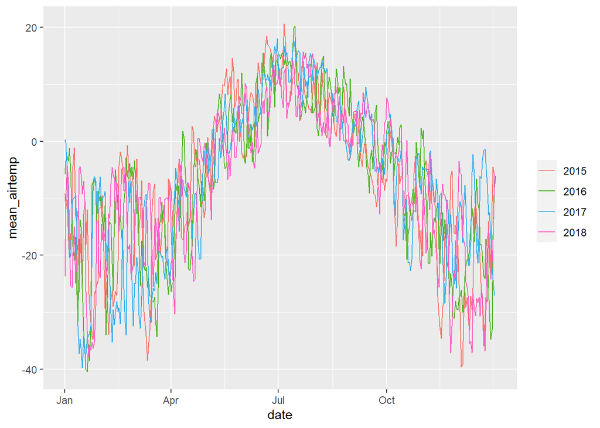

```r
toolik_ts %>%

  #filter(year(date) > 2014) %>%

  #Great for filtering between specific ranges
  filter_index("2015-01-01" ~ .) %>%

  #From feasts packages, assum want dates on x-axis
  gg_season(y = mean_airtemp)
```

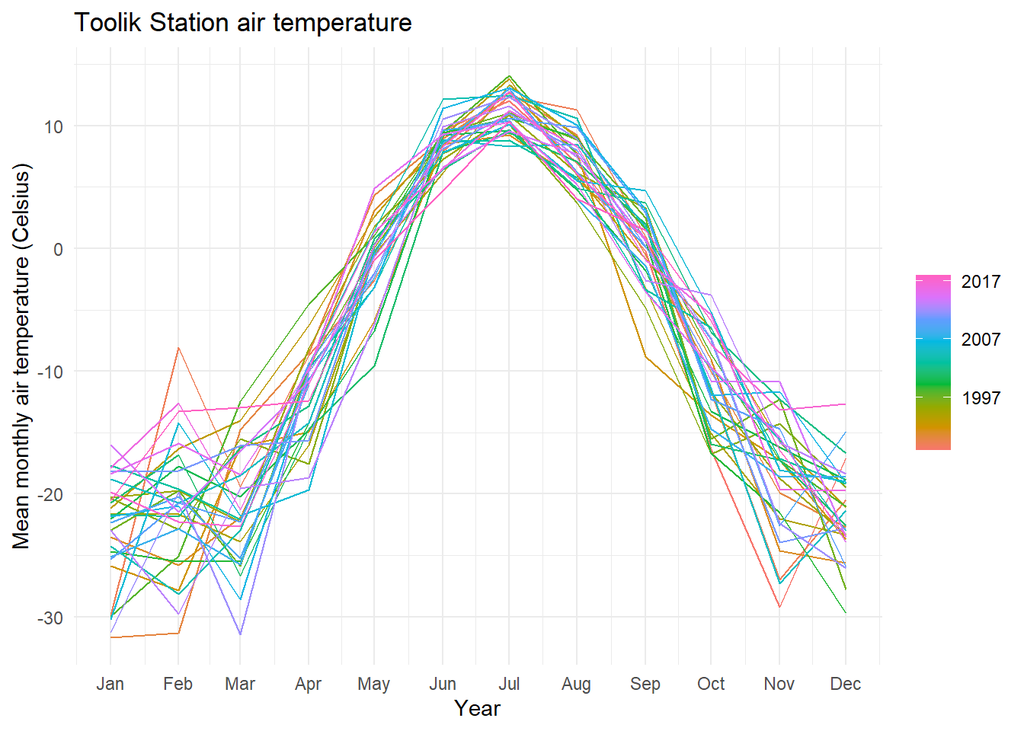

```r
# Now a season plot:
toolik_month %>%
  gg_season(y = monthly_mean_temp) +
  theme_minimal() +
  labs(x = "Year",
       y = "Mean monthly air temperature (Celsius)",
       title = "Toolik Station air temperature")
```

# Seasonal subseries plots

Subseries plot, how it changes between certain windows

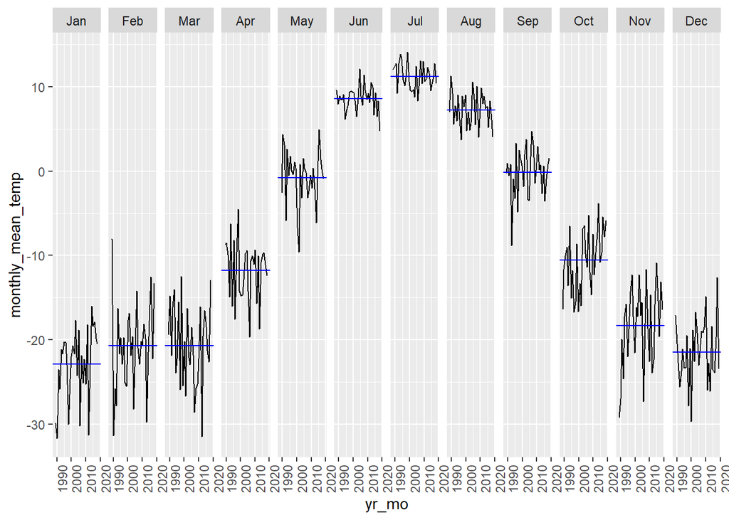

```r
toolik_month %>%
  gg_subseries(monthly_mean_temp)
```

Sometimes it can be useful to explore how values within one season/month/etc. change over time (e.g. across years).

We can use `gg_subseries()` to explore how values change within a specified window over time.

Do you notice any trends that differ across the months?

# Moving averages in tsibbles

We’ll use the `slider` package to find moving (or rolling) averages for different window sizes.

The general structure will tend to be something like:

`df %>% slide(variable, function, .before = , .after = )`

Let’s make a test vector just so we can see how this works:

```r
set.seed(2021)
test<- rnorm(n = 100, mean = 40, sd = 10)


#Create window around the 100 observations to create moving average (-/+ 1)

# Show the series based on values +2 and -2 from each observation (5 obser total)
# Use ~.x to show the windows
slide(test, ~.x, .before = 2, .after = 2)
```

```
## [[1]]
## [1] 38.77540 45.52457 43.48650
##
## [[2]]
## [1] 38.77540 45.52457 43.48650 43.59632
##
## [[3]]
## [1] 38.77540 45.52457 43.48650 43.59632 48.98054
##
## [[4]]
## [1] 45.52457 43.48650 43.59632 48.98054 20.77430
##
## [[5]]
## [1] 43.48650 43.59632 48.98054 20.77430 42.61744
##
## [[6]]
## [1] 43.59632 48.98054 20.77430 42.61744 49.15566
##
## [[7]]
## [1] 48.98054 20.77430 42.61744 49.15566 40.13772
##
## [[8]]
## [1] 20.77430 42.61744 49.15566 40.13772 57.29963
##
## [[9]]
## [1] 42.61744 49.15566 40.13772 57.29963 29.17795
##
## [[10]]
## [1] 49.15566 40.13772 57.29963 29.17795 37.27175
##
## [[11]]
## [1] 40.13772 57.29963 29.17795 37.27175 41.81995
##
## [[12]]
## [1] 57.29963 29.17795 37.27175 41.81995 55.08542
##
## [[13]]
## [1] 29.17795 37.27175 41.81995 55.08542 56.04470
##
## [[14]]
```

[output cut: 244 more lines]

```
##
## [[96]]
## [1] 47.35184 40.14985 38.77998 33.53226 31.32142
##
## [[97]]
## [1] 40.14985 38.77998 33.53226 31.32142 34.91300
##
## [[98]]
## [1] 38.77998 33.53226 31.32142 34.91300 19.22416
##
## [[99]]
## [1] 33.53226 31.32142 34.91300 19.22416
##
## [[100]]
## [1] 31.32142 34.91300 19.22416
```

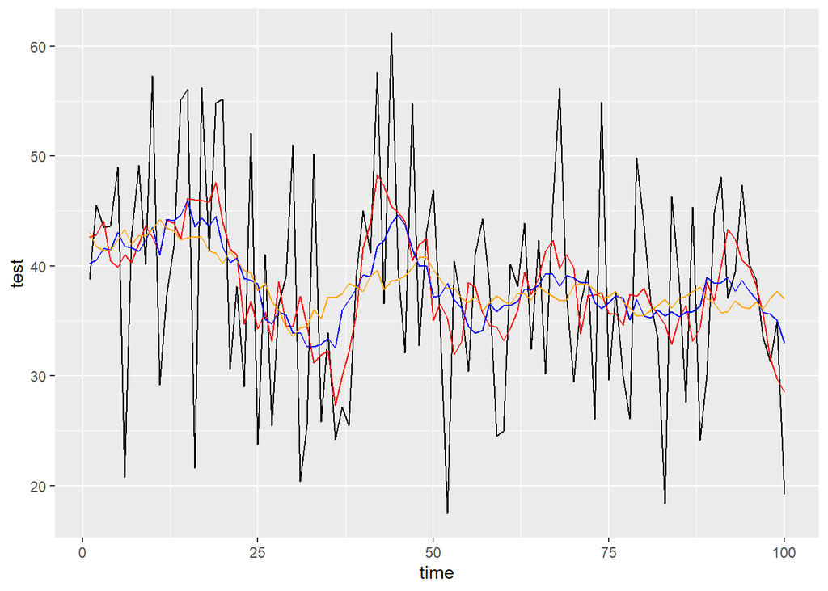

```r
# Change that to a function name to actually calculate something for each window
# Note that I add `as.numeric` here, since the outcome is otherwise a list
w5 <- as.numeric(slide(test, mean, .before = 2, .after = 2))
#w5

# Find the mean value of a window with n = 11, centered:
w11 <- as.numeric(slide(test, mean, .before = 5, .after = 5))
#w11

# Find the mean value of a window with n = 19, centered:
w19 <- as.numeric(slide(test, mean, .before = 9, .after = 9))
#w19

# Plot these together:
combo <- tibble(time = seq(1:100), test, w5, w11, w19)


ggplot(data = combo) +
  geom_line(aes(x = time, y = test)) +
  geom_line(aes(x = time, y = w5), color = "red") +
  geom_line(aes(x = time, y = w11), color = "blue") +
  geom_line(aes(x = time, y = w19), color = "orange")
```

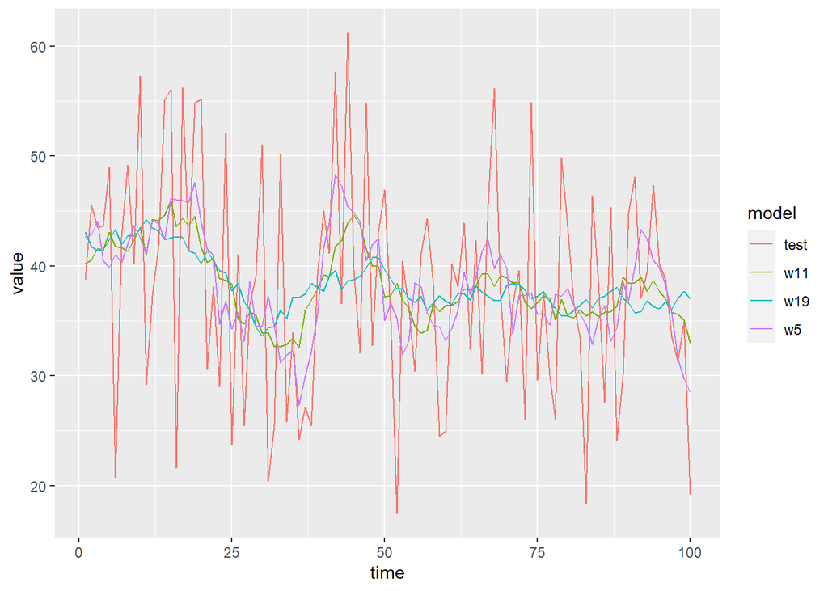

```r
#Plot after pivot
combo2 <- tibble(time = 1:100, test, w5, w11, w19) %>%
  pivot_longer(cols = test:w19, names_to = "model", values_to = "value")
ggplot(data = combo2) +
  geom_line(aes(x = time, y = value, color = model))
```

Now for an example with our Toolik Station data, let’s say we want to find the *average* value at each observation, with a window that extends forward and backward n days from the observation:

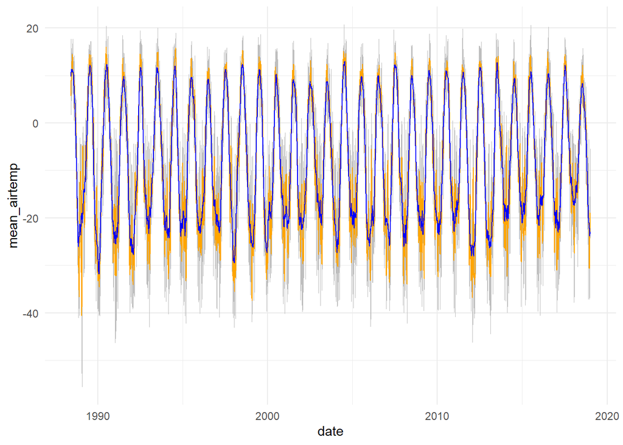

```r
#7 days before and after
roll_toolik_15 <- toolik_ts %>%
  mutate(ma_15d = as.numeric(slide(toolik_ts$mean_airtemp, mean, .before = 7, .after = 7)))

#30 days before and 30 after
roll_toolik_61 <- toolik_ts %>%
  mutate(ma_61d = as.numeric(slide(toolik_ts$mean_airtemp, mean, .before = 30, .after = 30)))

ggplot() +

  #Original data
  geom_line(data = toolik_ts, aes(x = date, y = mean_airtemp), size = 0.2, color = "gray") +

  #Based on moving average 15 day window
  geom_line(data = roll_toolik_15, aes(x = date, y = ma_15d), color = "orange") +

  #Based on moving average 30 day window
  geom_line(data = roll_toolik_61, aes(x = date, y = ma_61d), color = "blue") +
  theme_minimal()
```

Grey higher extremes above and below, but smoothed it out with averages, We see more seasonality more cleanly with the moving averages.

# Autocorrelation function

We’ll look at outcomes for both daily lags (yikes) and monthly lags (cool). Normally wouldn’t do this on a day-to-day basis because the weather yesterday will very similar to today and the next day.

For month, the ones closer to each other are more similar than months that are farther in lag.

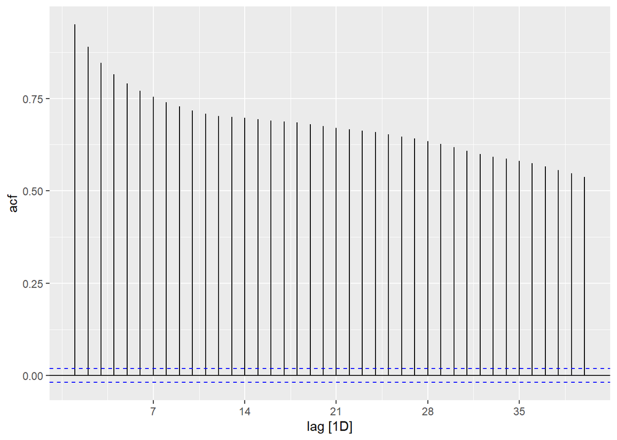

```r
#Use feasts package for auto plotting ACF
toolik_ts %>%
  ACF(mean_airtemp) %>%
  autoplot()
```

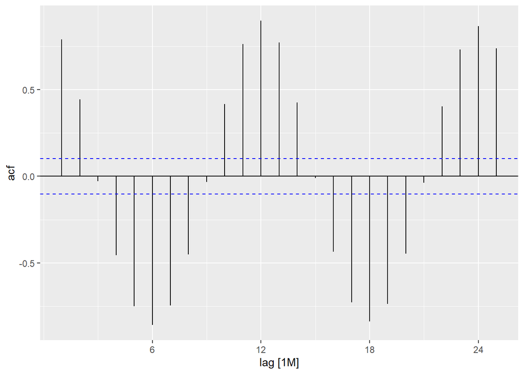

```r
toolik_month %>%
  ACF(monthly_mean_temp) %>%
  autoplot()
```

# Decomposition

Here we will use STL decomposition (Seasonal, Trend, and Loess) decomposition. You can read about the advantages of STL decomposition here: https://otexts.com/fpp2/stl.html.

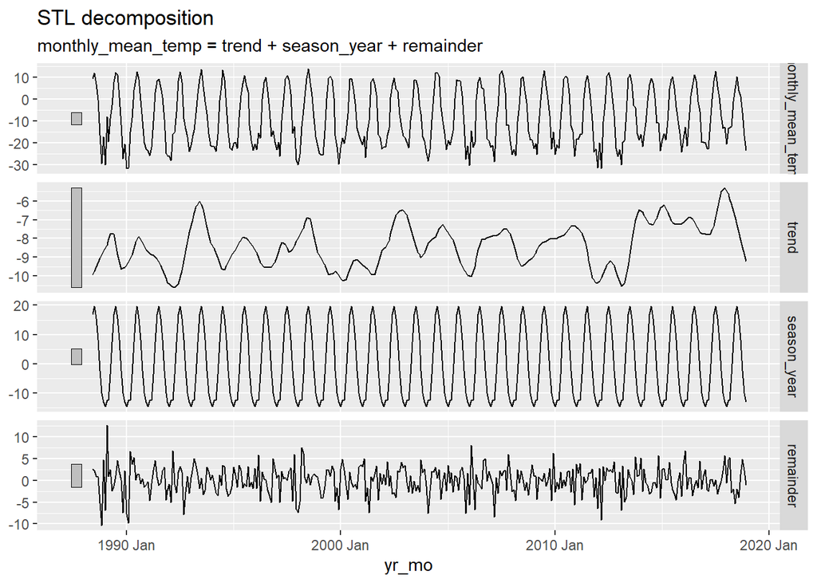

```r
toolik_dec <- toolik_month %>%
  model(STL(monthly_mean_temp ~ season(window = Inf)))

components(toolik_dec) %>% autoplot()
```